# Instructions on Preparing CRDMA Guide Documents

Style and compilation guidance

Paul Johnson

Center for Research Methods and Data Analysis, University of Kansas  
pauljohn@ku.edu

Zack Roman

Center for Research Methods and Data Analysis, University of Kansas  
zroman@ku.edu

Please visit http://crmda.ku.edu/guides for updates.

Tags: guides, markdown, guides

2017 August 08

Abstract

This instruction describes several key features/functionalities of R Markdown for producing colorful and vivid HTML format Guide documents. The demonstrations include embedding R code into an .Rmd file, inserting mathematical expressions (equations and matrices), and displaying R output and graphs/images. A careful study of this document will help learners to gain a basic understanding of the rmd2html workflow, especially when using it to create CRMDA Guide documents.

# CRMDA Guides

A guide is intended for students or other learners. It is not a format suitable for reports to clients or journal articles. A guide will generally include code and output excerpts.

# Using the `crmda` package

The crmda package provides template files and functions to convert from Rmarkdown to HTML and PDF format. This document is about the HTML “backend”. Different guides are needed for HTML and PDF backends because some features are unique.

The crmda package provides a cascading style sheet file that is intended to standardize our presentation across all guides. In order to begin with an R markdown guide, start R in a folder where you would like to create a write-up and run

```
> initWriteup("rmd2html-guide")
```

That should copy the template, this instruction document, and some other files into a directory named “writeup”. When the document is compiled, it will import some formatting information from the `crmda` package.

Open the file “guide-template.Rmd” in a text editor. Insert your name or a title and save the document.

The file can be compiled either by opening an R session and using the function `rmd2html()`, for example by running in R:

```
> library(crmda)
> rmd2html("guide-instructions.Rmd")
```

The `rmd2html` function allows other arguments that will be passed through to the render and html_document functions in the `Rmarkdown` and `knitr` packages for R. This is explained in the documentation.

It is not necessary to open R to compile this document. The output can also be generated by running a command line script that does the same work.

```
$ ./rmd2html.sh guide-instructions.Rmd
```

The rendered output (an HTML) file can be opened using Firefox or Chrome/Chromium.

```
$ firefox guide-instructions.html
```

If one uses Rstudio as a text editor for an Rmd file, one may not obtain satisfactory output by compiling the document with the built-in menu system because that menu system is not aware of the settings and cascading style sheet file that we are using. Avid Rstudio users can, we believe, customize their configurations to achieve satisfactory results.

# Document Preparation Basics

## Use a text editor

A markdown file is a “raw text” file. Don’t edit it with MS Word. Instead, use a programmers file editor, such as Emacs, Notepad++, or a integrated development environment, such as Rstudio, to edit the file.

We have three methods of beautifying text and creating structures.

## Rmarkdown

First, we have Rmarkdown formatting. Brief examples might include the fact that *italics* result from bracketing a word with asterixes (*italics*), **boldface** results from two asterixes (`**boldface**`). Section headers are defined by pound signs, where one pound sign is a “level 1” heading. There are 6 levels allowed. Numbered lists can be created by putting a number in column 1 of a new line, followed by a space. A bullet point list is created by putting an asterix in column 1 of a new line, followed by a space.

These examples indicate that Rmarkdown is similar to, but exactly the same, as the general Markdown standard (https://daringfireball.net/projects/markdown) or other dialects, such as GitHub Flavored Markdown (https://github.github.com/gfm). Advice for one dialect may not apply in an Rmarkdown document. Google searches will sometimes lead to the wrong answer for a particular form of Markdown.

For technical documentation, see

1. “R Markdown Reference Guide” (https://www.rstudio.com/wp-content/uploads/2015/03/rmarkdown-reference.pdf)
2. “R Markdown Cheatsheet” (https://www.rstudio.com/wp-content/uploads/2016/03/rmarkdown-cheatsheet-2.0.pdf)
3. Yihui Xie. 2015. *Dynamic Documents with R and Knitr. 2ed* Boca Raton, Florida: Chapman Hall/CRC. http://yihui.name/knitr. On July 7, 2017, Xie made available a new book manuscript, “bookdown: Authoring Books and Technical Documents with R Markdown” (https://bookdown.org/yihui/bookdown).

User-friendly overviews and tutorials on Rmarkdown usage are available.

1. The Rmarkdown page at Rstudio corporation, http://rmarkdown.rstudio.com. There is general information and an Rmarkdown “Get Started” Tutorial, http://rmarkdown.rstudio.com/lesson-1.html. The Rstudio corporation employs many of the leading developers of R markdown.
2. Cosma Shalizi, “Using R Markdown for Class Reports”, http://www.stat.cmu.edu/~cshalizi/rmarkdown.

Because the document translation *pandoc* plays a critical role in the conversion of documents from markdown into HTML, documentation for pandoc will often be definitive. Along those lines, we point readers to the Pandoc Markdown reference manual at Rstudio: http://rmarkdown.rstudio.com/authoring_pandoc_markdown.html.

## Raw HTML

Because this document will eventually be compiled into an HTML file, we are allowed to insert HTML tags. While the Markdown movement is no doubt inspired by disappointment with the complicated, unreadable nature of HTML code, it does not prevent the use of HTML markup (“markdown” is a play on words, to be the opposite of “markup”). Rather than the simpler markdown, for example, one might write HTML **bold** or bold in another way in HTML. The HTML markup for these, `<b>bold</b>` or `<span style="font-weight:bold">bold in another way</span>` is arguably less readable, but it is allowed. The key point is the following: If something is unavailable in the Rmarkdown toolkit, one can directly write with HTML to achieve the purpose.

Using raw HTML markup might be considered a defeat for the would-be Rmarkdown document writer, but sometimes (perhaps less often now than a year ago) HTML markup is the only workable option.

The document translation software is surprisingly effective at converting special characters. For example, in HTML documents, one cannot use the less than or greater than symbols in text because they are markdown separators. In HTML, one would need to insert `&lt;` to represent $<$. The document conversion programs are aware of this, however, so that symbols in the markdown file that would ordinarily “break” the HTML document, like < , >, or &, are gracefully (automatically) converted to `&lt;`, `&gt;` and `&amp;`.

Similarly, a forbidden dollar sign in $234.23 would ordinarly crash a LaTeX document, where one would be required to escape the dollar sign, `\$234.23`, but the Rmarkdown conversion process seems to handle the un-escaped dollar sign gracefully.

## $\LaTeX$ markup

$\LaTeX$ markup for math can be used within the Rmd file. This is **not** a sure-fire success. The HTML document will not be readable in all Web browsers. The central problem is that the HTML output file contains a form of markup that is converted–in the Web browser–via javascript and functions supplied interactively from the MathJax Web server. The $\LaTeX$ result is not “embedded” in the HTML, it is instead “available for rendering” in the Webpage. Over the years, however, we observe that the MathJax display system works better and better and today, for the most part, it *almost always works* if users are online when they try to browse the HTML file and if javascript blockers do not interfere with the rendering process in the Web browser. If a user is offline, or the MathJax web server is not responding, the raw markup will appear. Users will see $$ rather than $\LaTeX$.

Unlike HTML code, not all $\LaTeX$ markdown is allowed in an Rmarkdown document. One cannot insert italics with $\LaTeX$.  
Inserting `\emph{italics}` or bold `\textbf{bold}` in the style of $\LaTeX$ code will have no effect.

Rmarkdown allows the insertion of in-line math markup in the same way that math is introduced in $\LaTeX$ documents. Code is bracketed with dollar signs, as in `$\alpha$` to write $\alpha$ or `$\f_{ij} x_{i} \times y{j}^2$` to write $\f_{ij} x_{i} \times y{j}$.

Displayed equations–equations that are centered or otherwise set apart from the text–can be created in several ways. Although the double-dollar sign method is allowed, it is suggested instead to bracket a displayed equation with `\[` and `\]`. Compare the inline mode, $\bar{x} = \frac{1}{n} \sum_{i=1}^{n}x_{i}$ (from `$\bar{x} = \frac{1}{n} \sum_{i=1}^{n}x_{i}$`) with the display equation output:

$$\bar{x} = \frac{1}{n} \sum_{i=1}^{n}x_{i}$$

that results from

```
\[
\bar{x} = \frac{1}{n} \sum_{i=1}^{n}x_{i}
\]
```

$\LaTeX$ has several math-customized packages that are widely used and we run into contradictory advice about how to write equations.

One can also use the $\LaTeX$ `\begin{equation}`, which comes from the $\LaTeX$ package *amsmath*.

$$\begin{equation}
A_{m,n} = \left(\begin{array}{ccc}
a & b & c\\
d & e & f\\
g & h & i\\
\end{array}\right)
\label{eq:another1}
\end{equation}$$

We don’t know if there is a comprehensive list of which $\LaTeX$ math symbols are allowed, but we wish somebody would find one. Here are formulae that do work.

We have success with all of the usual $\LaTeX$ methods to create fractions, $\frac{2}{3}$, hats, $\hat{\lambda}$, $\sqrt{square~roots}$, binary operators, $+$ $-$ $\times$ $=$ $\approx$ $\ne$ $\ge$ $\lt$ $\pm$ $\sim$ $\rightarrow$, symbols like $\pi$ and $\infty$, and all Greek letters are available.

This is not the right place for a comprehensive guide to $\LaTeX$. Users will need to install a $\LaTeX$ distribution and then a user-friendly editor that will help create equation markup. Many users in the CRMDA lab use LyX, which offers a “View source” feature to inspect $\LaTeX$ coding for equations.

### Equation Numbering

To designate numbered equations, we can manually assign equation numbers. Unfortunately, markdown to HTML does not support auto-numbering equations by default. However, you can designate static equation numbers by adding`\tag{}` to the end of equations:

$$+ - = \approx \ne \ge \lt \pm\tag{1}$$
$$\pi \approx 3.1415927\tag{2}$$
$$a_i \ge 0~~~\forall i\tag{3}$$
$$x \lt 15\tag{4}$$

## Knit (incorporate R code and output)

A code chunk is a runable piece of R code. As the Rmd file is compiled, its results of chunks are accumulated in an R session. One can run a command and then refer to its output in following chunks. This makes it convenient to introduce R examples for readers.

In a $\LaTeX$ document, for which this technology was invented, the code chunks are created by a somewhat cumbersome notation:

```
<<>>=
lm(y ~ x, data = dat)
@
```

In Rmarkdown, the outer boundaries are changed to three back ticks, along with squiggly braces.

`` ```{r} ``

`lm(y ~ x, data = dat)`

`` ``` ``

This allows for the full functionality of the R programming environment to be “knitted” into a markdown report. Code chunks have many options which can be aplied to change the functionality of a specific chunk. The following link presents a well organized list of some potential chunk options.

https://yihui.name/knitr/options/

### Plots

Plots or figures can be added to any Markdown document through the use of R code chunks.

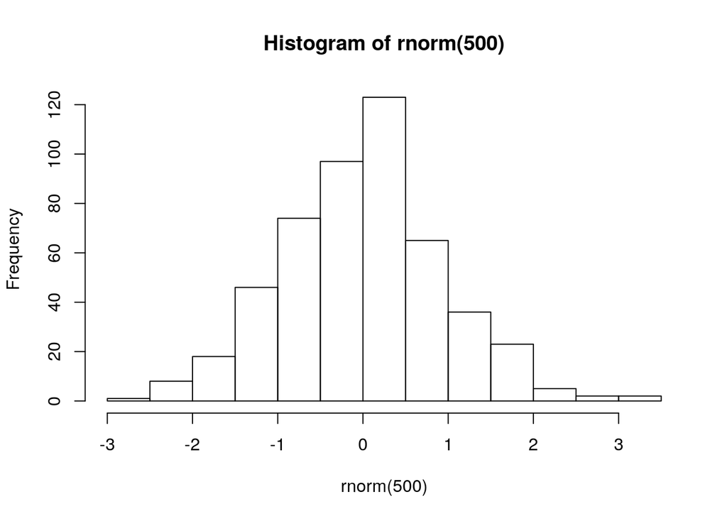

```r
hist(rnorm(500))
```

```r
x <- rnorm(1000)
print(x[1:20])
```

```
 [1] -1.24037557  0.15537344  0.08757943 -0.37366801 -0.54317262
 [6] -1.16783519 -3.21039703  0.61771668  0.13374916 -0.48932706
[11] -0.09024610  0.32214273  0.06163087 -0.25296555 -0.18947404
[16]  0.53317636  0.14491347 -0.72553661 -0.45919134  0.72527120
```

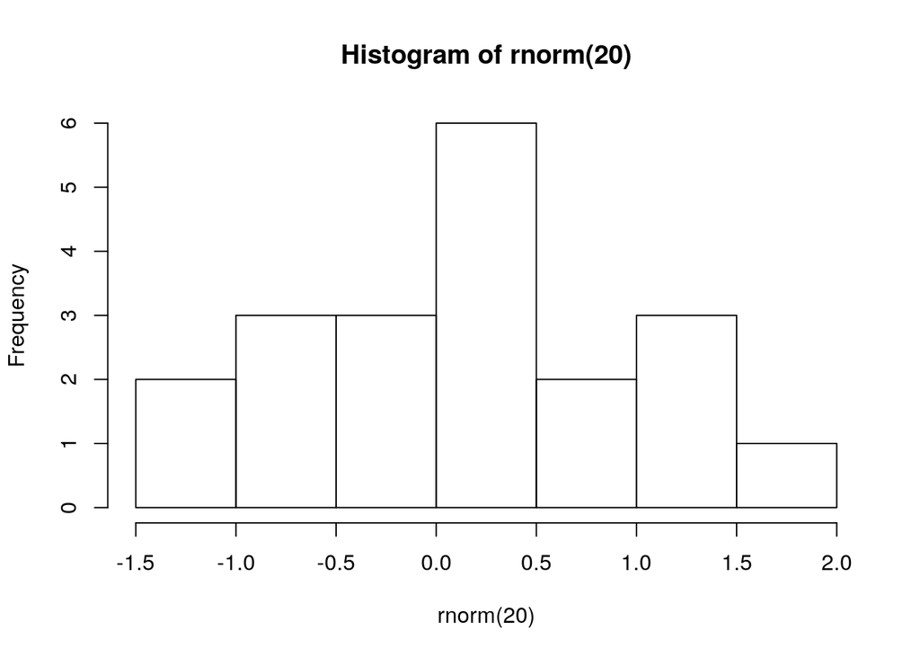

```r
hist(rnorm(20))
```

### Tables

Here is an example of the rockchalk packages model comparison table

```r
cat(or1)
```

Amod

Bmod

Gmod

Estimate

Estimate

Estimate

(S.E.)

(S.E.)

(S.E.)

(Intercept)

30.245***

29.774***

30.013***

(0.618)

(0.522)

(0.490)

x1

1.546*

.

2.217***

(0.692)

(0.555)

x2

.

3.413***

3.717***

(0.512)

(0.483)

N

100

100

100

RMSE

6.121

5.205

4.849

R<sup>2</sup>

0.048

0.312

0.409

adj R<sup>2</sup>

0.039

0.305

0.397

- p ≤0.05** p ≤0.01*** p ≤0.001

We have settled on Xtable as a great table producing package which offers flexability and functionality.

```r
    library(xtable)
    or2 <- xtable(summary(m1))
    print(or2, type="html")
```

|  | Estimate | Std. Error | t value | Pr(>\|t\|) |
| --- | --- | --- | --- | --- |
| (Intercept) | 30.2455 | 0.6176 | 48.97 | 0.0000 |
| x1 | 1.5455 | 0.6924 | 2.23 | 0.0279 |

```r
    library(psych)
print(xtable(describe(dat)),type = "html")
```

|  | vars | n | mean | sd | median | trimmed | mad | min | max | range | skew | kurtosis | se |
| --- | --- | --- | --- | --- | --- | --- | --- | --- | --- | --- | --- | --- | --- |
| x1 | 1 | 100.00 | -0.12 | 0.89 | -0.03 | -0.10 | 0.99 | -2.61 | 1.91 | 4.53 | -0.30 | -0.12 | 0.09 |
| x2 | 2 | 100.00 | 0.08 | 1.02 | 0.20 | 0.12 | 0.98 | -2.56 | 2.23 | 4.79 | -0.36 | -0.29 | 0.10 |
| y1 | 3 | 100.00 | 30.06 | 6.24 | 30.65 | 30.06 | 6.38 | 16.59 | 48.44 | 31.85 | 0.04 | -0.28 | 0.62 |
| y2 | 4 | 100.00 | 0.25 | 5.16 | 0.72 | 0.39 | 4.53 | -13.20 | 11.32 | 24.52 | -0.27 | -0.27 | 0.52 |

# Special Features for Rmd into HTML documents.

HTML documents allow for interactivity as compared to other forms of markdown output. Below are some unique features we take advantage of in HTML output.

## Collored Callouts

Callouts allow the user to specify code chunks, tables, plots, or paragraphs to be collored. This is a great way to get your readers attention. These are always preceded by four # signs. Yes, ####. We stole this idea from other styles and put them into ours. See usage of {.bs-callout.bs-callout-whatever_you_put here}, where whatever_you_put_here iseither “gray”, “red”, “orange”, “blue”, or “green”.

### Demonstrating Callouts

#### Gray Callout

Content here: Gray for wisdom

#### Red Callout

Red for warnings

#### Orange Callout

Orange for examples

#### Blue Callout

Blue for right answers

#### Green Callout

Green for future directions

#### R code inside a callout

```r
summary(x)
```

```
     Min.   1st Qu.    Median      Mean   3rd Qu.      Max.
-3.210397 -0.642879 -0.003941 -0.011916  0.670569  2.794934
```

## Interactive Tabs

If you’d like, you can include interactive tabs to HTML reports. Maybe you want to show two similar versions of the same analysis. Or maybe something else. Whatever it may be, be sure to include `{.tabset .tabset-fade}` along with a level 2 header (##). For each tab, put the information under the level 3 header (###). Use another level 2 header to get out of the tabs mode.

```
## You have the ability to include tabs {.tabset .tabset-fade}

If you'd like, you can include different tabs. Maybe you want to show
two similar versions of the same analysis. Or maybe something
else. Whatever it may be, be sure to include `{.tabset .tabset-fade}`
along with a level 2 header (##). For each tab, put the information
under the level 3 header (###). Use another level 2 header to get out
of the tabs mode.

The only way (that we know of) to get colors is to wrap the tab
headers in a `<span style>` as shown below. This might be useful to
draw attention to the tabs. Blue is the default color.

### <span style="color:red">First Tab Here</span>

Some information you'd like to show.

### <span style="color:orange">Second Tab Here</span>

Some more information you'd like to show.

Some more information you'd like to show.

### Third Tab Here

Some final information you'd like to show.

Some final information you'd like to show.

Some final information you'd like to show.
```

### First Tab Here

Some information you’d like to show.

### Second Tab Here

Some more information you’d like to show.

Some more information you’d like to show.

### Third Tab Here

Some final information you’d like to show.

Some final information you’d like to show.

Some final information you’d like to show.

## International characters

Accented letters, often in non-English names, like

Karl Gustav Jöreskog and Dag Sörbom

Linda Muthén and Bengt Muthén

# Policies about writing in these documents.

1. Use these callouts to attract attention.
2. Blank rows separate paragraphs.
3. The character width of rows should be 80 or less. I have no idea how anybody thinks they have a right to impose an infinitely long row, but it’s bad. Edit the document with Emacs, run M-q to get re-positioned text. If your editor cannot do that, quit using it.
4. Must make sure compiling using the kutils.css located in the crmda package. For example, `crmda::rmd2html("filename.Rmd")`

[output not shown]

Available under Created Commons license 3.0

[figure not shown]